# Elastic net Regression Project

### Imports

```python
import numpy as np
import pandas as pd
import matplotlib.pyplot as plt
import seaborn as sns
```

### Data

```python
df = pd.read_csv("../DATA/AMES_Housing_Data.csv")
df.head()
```

|  | PID | MS SubClass | MS Zoning | Lot Frontage | Lot Area | Street | Alley | Lot Shape | Land Contour | Utilities | ... | Pool Area | Pool QC | Fence | Misc Feature | Misc Val | Mo Sold | Yr Sold | Sale Type | Sale Condition | SalePrice |
| --- | --- | --- | --- | --- | --- | --- | --- | --- | --- | --- | --- | --- | --- | --- | --- | --- | --- | --- | --- | --- | --- |
| 0 | 526301100 | 20 | RL | 141.0 | 31770 | Pave | NaN | IR1 | Lvl | AllPub | ... | 0 | NaN | NaN | NaN | 0 | 5 | 2010 | WD | Normal | 215000 |
| 1 | 526350040 | 20 | RH | 80.0 | 11622 | Pave | NaN | Reg | Lvl | AllPub | ... | 0 | NaN | MnPrv | NaN | 0 | 6 | 2010 | WD | Normal | 105000 |
| 2 | 526351010 | 20 | RL | 81.0 | 14267 | Pave | NaN | IR1 | Lvl | AllPub | ... | 0 | NaN | NaN | Gar2 | 12500 | 6 | 2010 | WD | Normal | 172000 |
| 3 | 526353030 | 20 | RL | 93.0 | 11160 | Pave | NaN | Reg | Lvl | AllPub | ... | 0 | NaN | NaN | NaN | 0 | 4 | 2010 | WD | Normal | 244000 |
| 4 | 527105010 | 60 | RL | 74.0 | 13830 | Pave | NaN | IR1 | Lvl | AllPub | ... | 0 | NaN | MnPrv | NaN | 0 | 3 | 2010 | WD | Normal | 189900 |

5 rows × 81 columns

```python
df.info()
```

```
<class 'pandas.core.frame.DataFrame'>
RangeIndex: 2930 entries, 0 to 2929
Data columns (total 81 columns):
 #   Column           Non-Null Count  Dtype
---  ------           --------------  -----
 0   PID              2930 non-null   int64
 1   MS SubClass      2930 non-null   int64
 2   MS Zoning        2930 non-null   object
 3   Lot Frontage     2440 non-null   float64
 4   Lot Area         2930 non-null   int64
 5   Street           2930 non-null   object
 6   Alley            198 non-null    object
 7   Lot Shape        2930 non-null   object
 8   Land Contour     2930 non-null   object
 9   Utilities        2930 non-null   object
```

[output cut: 73 more lines]

### Data Preparation

**Checking for outliers**

```python
df.corr(numeric_only=True)['SalePrice'].sort_values()
```

```
PID               -0.246521
Enclosed Porch    -0.128787
Kitchen AbvGr     -0.119814
Overall Cond      -0.101697
MS SubClass       -0.085092
Low Qual Fin SF   -0.037660
Bsmt Half Bath    -0.035835
Yr Sold           -0.030569
Misc Val          -0.015691
BsmtFin SF 2       0.005891
3Ssn Porch         0.032225
Mo Sold            0.035259
Pool Area          0.068403
Screen Porch       0.112151
Bedroom AbvGr      0.143913
Bsmt Unf SF        0.182855
Lot Area           0.266549
2nd Flr SF         0.269373
Bsmt Full Bath     0.276050
Half Bath          0.285056
Open Porch SF      0.312951
Wood Deck SF       0.327143
Lot Frontage       0.357318
BsmtFin SF 1       0.432914
Fireplaces         0.474558
TotRms AbvGrd      0.495474
Mas Vnr Area       0.508285
Garage Yr Blt      0.526965
Year Remod/Add     0.532974
Full Bath          0.545604
Year Built         0.558426
1st Flr SF         0.621676
Total Bsmt SF      0.632280
Garage Area        0.640401
Garage Cars        0.647877
Gr Liv Area        0.706780
Overall Qual       0.799262
SalePrice          1.000000
Name: SalePrice, dtype: float64
```

Overall Quality has the highest correlation with saleprice.

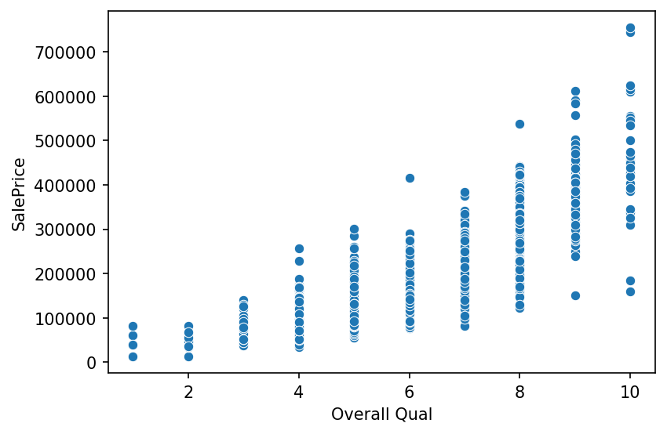

```python
plt.figure(figsize=(6,4), dpi=150)
sns.scatterplot(data=df, x = 'Overall Qual', y = 'SalePrice');
```

There seem to be a few outliers but only three seem problematic. Extremely high prices for high overall quality follow the correct trend. On the other hand, the three houses with an overell quality of 9-10 that are selling at very low prices do not follow the right trend and are worth looking into. Let's look at the second most correlated feature Gr Liv Area.

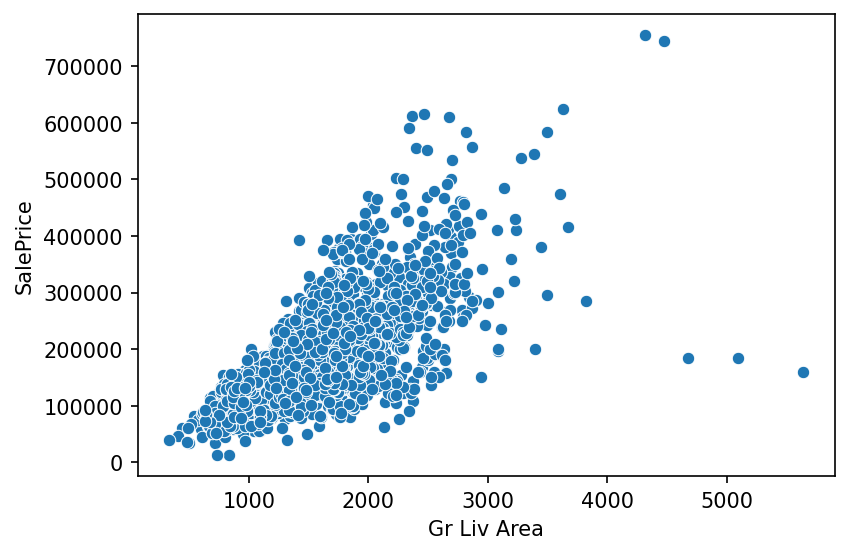

```python
plt.figure(figsize=(6,4), dpi=150)
sns.scatterplot(data=df, x = 'Gr Liv Area', y = 'SalePrice');
```

Three outliers are again visible, this time on another feature. These might influence our eventual model. Let's remove these

```python
GLA_outliers_idx = df[(df['Gr Liv Area'] > 4000) & (df['SalePrice'] < 400000)].index
GLA_outliers_idx
```

```
Index([1498, 2180, 2181], dtype='int64')
```

```python
OQ_outliers_idx = df[(df['Overall Qual'] > 8 ) & (df['SalePrice'] < 200000)].index
OQ_outliers_idx
```

```
Index([1182, 1498, 2180, 2181], dtype='int64')
```

```python
three_outliers = [x for x in OQ_outliers_idx if x in GLA_outliers_idx]
three_outliers
```

```
[1498, 2180, 2181]
```

Removing the outliers that are present in both features

```python
df = df.drop(three_outliers, axis=0)
```

Repeat previous scatter plot

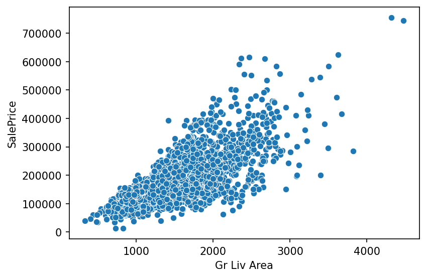

```python
plt.figure(figsize=(6,4), dpi=150)
sns.scatterplot(data=df, x = 'Gr Liv Area', y = 'SalePrice');
```

**Missing Data**

importing the feature description file

```python
with open('../DATA/Ames_Housing_Feature_Description.txt', 'r') as f:
    print(f.read())
```

```
MSSubClass: Identifies the type of dwelling involved in the sale.

        20	1-STORY 1946 & NEWER ALL STYLES
        30	1-STORY 1945 & OLDER
        40	1-STORY W/FINISHED ATTIC ALL AGES
        45	1-1/2 STORY - UNFINISHED ALL AGES
        50	1-1/2 STORY FINISHED ALL AGES
        60	2-STORY 1946 & NEWER
        70	2-STORY 1945 & OLDER
        75	2-1/2 STORY ALL AGES
        80	SPLIT OR MULTI-LEVEL
        85	SPLIT FOYER
        90	DUPLEX - ALL STYLES AND AGES
       120	1-STORY PUD (Planned Unit Development) - 1946 & NEWER
       150	1-1/2 STORY PUD - ALL AGES
       160	2-STORY PUD - 1946 & NEWER
       180	PUD - MULTILEVEL - INCL SPLIT LEV/FOYER
       190	2 FAMILY CONVERSION - ALL STYLES AND AGES

MSZoning: Identifies the general zoning classification of the sale.

       A	Agriculture
       C	Commercial
       FV	Floating Village Residential
       I	Industrial
       RH	Residential High Density
       RL	Residential Low Density
       RP	Residential Low Density Park
       RM	Residential Medium Density

LotFrontage: Linear feet of street connected to property

LotArea: Lot size in square feet

Street: Type of road access to property

       Grvl	Gravel
       Pave	Paved

Alley: Type of alley access to property
```

[output cut: 468 more lines]

```
       COD	Court Officer Deed/Estate
       Con	Contract 15% Down payment regular terms
       ConLw	Contract Low Down payment and low interest
       ConLI	Contract Low Interest
       ConLD	Contract Low Down
       Oth	Other

SaleCondition: Condition of sale

       Normal	Normal Sale
       Abnorml	Abnormal Sale -  trade, foreclosure, short sale
       AdjLand	Adjoining Land Purchase
       Alloca	Allocation - two linked properties with separate deeds, typically condo with a garage unit
       Family	Sale between family members
       Partial	Home was not completed when last assessed (associated with New Homes)
```

```python
df.head()
```

|  | PID | MS SubClass | MS Zoning | Lot Frontage | Lot Area | Street | Alley | Lot Shape | Land Contour | Utilities | ... | Pool Area | Pool QC | Fence | Misc Feature | Misc Val | Mo Sold | Yr Sold | Sale Type | Sale Condition | SalePrice |
| --- | --- | --- | --- | --- | --- | --- | --- | --- | --- | --- | --- | --- | --- | --- | --- | --- | --- | --- | --- | --- | --- |
| 0 | 526301100 | 20 | RL | 141.0 | 31770 | Pave | NaN | IR1 | Lvl | AllPub | ... | 0 | NaN | NaN | NaN | 0 | 5 | 2010 | WD | Normal | 215000 |
| 1 | 526350040 | 20 | RH | 80.0 | 11622 | Pave | NaN | Reg | Lvl | AllPub | ... | 0 | NaN | MnPrv | NaN | 0 | 6 | 2010 | WD | Normal | 105000 |
| 2 | 526351010 | 20 | RL | 81.0 | 14267 | Pave | NaN | IR1 | Lvl | AllPub | ... | 0 | NaN | NaN | Gar2 | 12500 | 6 | 2010 | WD | Normal | 172000 |
| 3 | 526353030 | 20 | RL | 93.0 | 11160 | Pave | NaN | Reg | Lvl | AllPub | ... | 0 | NaN | NaN | NaN | 0 | 4 | 2010 | WD | Normal | 244000 |
| 4 | 527105010 | 60 | RL | 74.0 | 13830 | Pave | NaN | IR1 | Lvl | AllPub | ... | 0 | NaN | MnPrv | NaN | 0 | 3 | 2010 | WD | Normal | 189900 |

5 rows × 81 columns

PID is just a unique identifier, however the indices serve this purpose fine

```python
df = df.drop('PID', axis=1)
```

```python
df.isnull().sum()
```

```
MS SubClass         0
MS Zoning           0
Lot Frontage      490
Lot Area            0
Street              0
                 ...
Mo Sold             0
Yr Sold             0
Sale Type           0
Sale Condition      0
SalePrice           0
Length: 80, dtype: int64
```

```python
def missing_data(df):
    percent_missing = 100 * df.isnull().sum() / len(df)
    percent_missing = percent_missing[percent_missing > 0].sort_values()

    return percent_missing
```

```python
percent_nan = missing_data(df)
percent_nan
```

```
Electrical         0.034165
Garage Cars        0.034165
BsmtFin SF 1       0.034165
Garage Area        0.034165
BsmtFin SF 2       0.034165
Bsmt Unf SF        0.034165
Total Bsmt SF      0.034165
Bsmt Half Bath     0.068329
Bsmt Full Bath     0.068329
Mas Vnr Area       0.785787
Bsmt Qual          2.733174
Bsmt Cond          2.733174
BsmtFin Type 1     2.733174
BsmtFin Type 2     2.767339
Bsmt Exposure      2.835668
Garage Type        5.363854
Garage Qual        5.432183
Garage Cond        5.432183
Garage Yr Blt      5.432183
Garage Finish      5.432183
Lot Frontage      16.740690
Fireplace Qu      48.582166
Mas Vnr Type      60.642296
Fence             80.457807
Alley             93.235395
Misc Feature      96.412709
Pool QC           99.590024
dtype: float64
```

Visualize the percentage missing

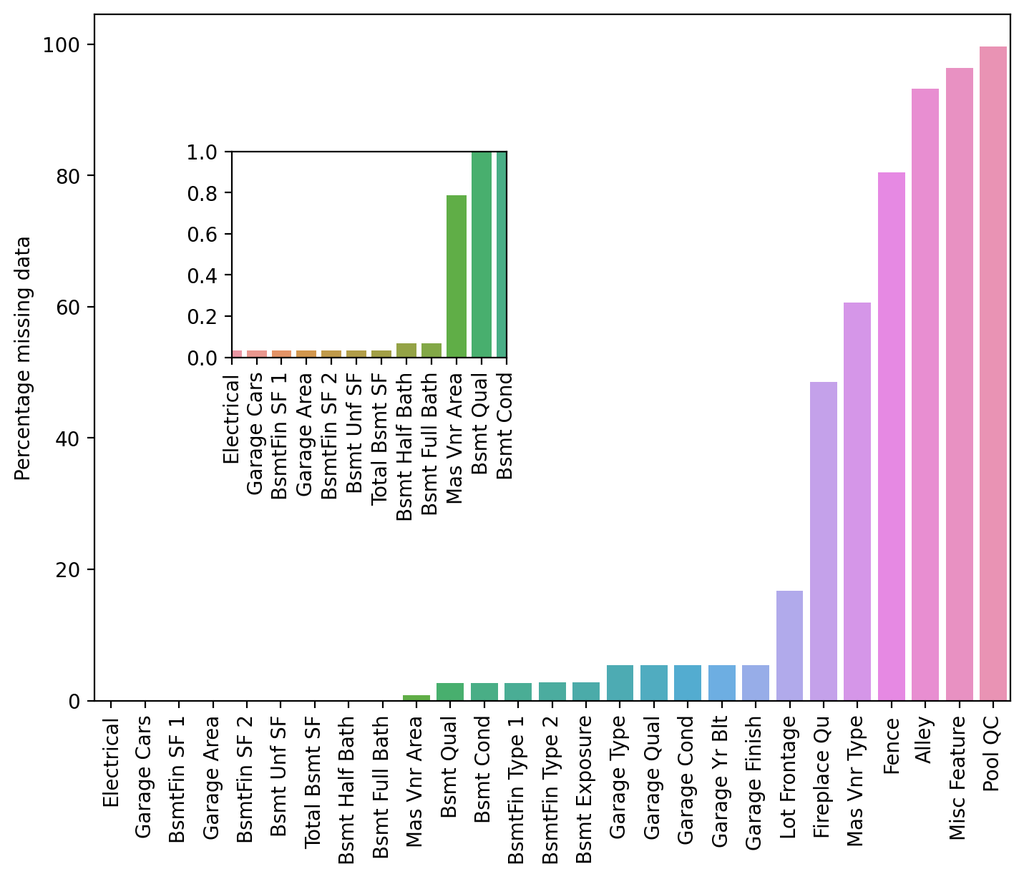

```python
fig = plt.figure(dpi=200)
ax1 = fig.add_axes([0,0,1,1])
ax2 = fig.add_axes([0.15,0.5,0.3,0.3])

sns.barplot(x=percent_nan.index, y=percent_nan, ax=ax1)
ax1.tick_params(axis='x', rotation=90)
ax1.set_ylabel('Percentage missing data')


sns.barplot(x=percent_nan.index, y=percent_nan, ax=ax2)
ax2.set_xlim(0,11)
ax2.set_ylim(0,1)
ax2.tick_params(axis='x', rotation=90)
```

Feature-ROWS with less than one percentage missing data can be dropped.

```python
percent_nan[percent_nan < 1]
```

```
Electrical        0.034165
Garage Cars       0.034165
BsmtFin SF 1      0.034165
Garage Area       0.034165
BsmtFin SF 2      0.034165
Bsmt Unf SF       0.034165
Total Bsmt SF     0.034165
Bsmt Half Bath    0.068329
Bsmt Full Bath    0.068329
Mas Vnr Area      0.785787
dtype: float64
```

```python
100 / len(df)
```

```
0.0341646737273659
```

0.034165 indicates that only one row is missing

```python
df[df['Electrical'].isnull()]['Garage Area']
```

```
1577    400.0
Name: Garage Area, dtype: float64
```

The row that is missing Electrical data is not the same as the row that is misisng Garage Area. Hopefully by dropping both, a lot of the one percenters will drop as well.

```python
df = df.dropna(axis=0, subset=['Electrical', 'Garage Area'])
```

```python
percent_nan = missing_data(df)
percent_nan[percent_nan < 1]
```

```
Bsmt Unf SF       0.034188
Total Bsmt SF     0.034188
BsmtFin SF 2      0.034188
BsmtFin SF 1      0.034188
Bsmt Full Bath    0.068376
Bsmt Half Bath    0.068376
Mas Vnr Area      0.786325
dtype: float64
```

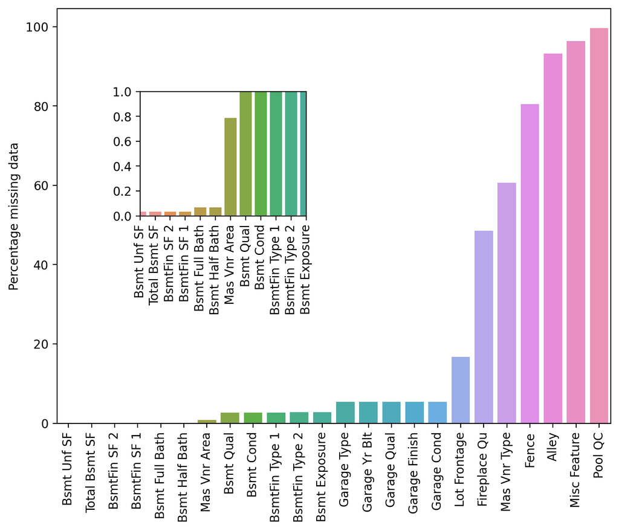

```python
fig = plt.figure(dpi=200)
ax1 = fig.add_axes([0,0,1,1])
ax2 = fig.add_axes([0.15,0.5,0.3,0.3])

sns.barplot(x=percent_nan.index, y=percent_nan, ax=ax1)
ax1.tick_params(axis='x', rotation=90)
ax1.set_ylabel('Percentage missing data')


sns.barplot(x=percent_nan.index, y=percent_nan, ax=ax2)
ax2.set_xlim(0,11)
ax2.set_ylim(0,1)
ax2.tick_params(axis='x', rotation=90)
```

```python
df[df['Bsmt Half Bath'].isnull()]
```

|  | MS SubClass | MS Zoning | Lot Frontage | Lot Area | Street | Alley | Lot Shape | Land Contour | Utilities | Lot Config | ... | Pool Area | Pool QC | Fence | Misc Feature | Misc Val | Mo Sold | Yr Sold | Sale Type | Sale Condition | SalePrice |
| --- | --- | --- | --- | --- | --- | --- | --- | --- | --- | --- | --- | --- | --- | --- | --- | --- | --- | --- | --- | --- | --- |
| 1341 | 20 | RM | 99.0 | 5940 | Pave | NaN | IR1 | Lvl | AllPub | FR3 | ... | 0 | NaN | MnPrv | NaN | 0 | 4 | 2008 | ConLD | Abnorml | 79000 |
| 1497 | 20 | RL | 123.0 | 47007 | Pave | NaN | IR1 | Lvl | AllPub | Inside | ... | 0 | NaN | NaN | NaN | 0 | 7 | 2008 | WD | Normal | 284700 |

2 rows × 80 columns

```python
df[df['Bsmt Full Bath'].isnull()]
```

|  | MS SubClass | MS Zoning | Lot Frontage | Lot Area | Street | Alley | Lot Shape | Land Contour | Utilities | Lot Config | ... | Pool Area | Pool QC | Fence | Misc Feature | Misc Val | Mo Sold | Yr Sold | Sale Type | Sale Condition | SalePrice |
| --- | --- | --- | --- | --- | --- | --- | --- | --- | --- | --- | --- | --- | --- | --- | --- | --- | --- | --- | --- | --- | --- |
| 1341 | 20 | RM | 99.0 | 5940 | Pave | NaN | IR1 | Lvl | AllPub | FR3 | ... | 0 | NaN | MnPrv | NaN | 0 | 4 | 2008 | ConLD | Abnorml | 79000 |
| 1497 | 20 | RL | 123.0 | 47007 | Pave | NaN | IR1 | Lvl | AllPub | Inside | ... | 0 | NaN | NaN | NaN | 0 | 7 | 2008 | WD | Normal | 284700 |

2 rows × 80 columns

```python
df[df['Bsmt Unf SF'].isnull()]
```

|  | MS SubClass | MS Zoning | Lot Frontage | Lot Area | Street | Alley | Lot Shape | Land Contour | Utilities | Lot Config | ... | Pool Area | Pool QC | Fence | Misc Feature | Misc Val | Mo Sold | Yr Sold | Sale Type | Sale Condition | SalePrice |
| --- | --- | --- | --- | --- | --- | --- | --- | --- | --- | --- | --- | --- | --- | --- | --- | --- | --- | --- | --- | --- | --- |
| 1341 | 20 | RM | 99.0 | 5940 | Pave | NaN | IR1 | Lvl | AllPub | FR3 | ... | 0 | NaN | MnPrv | NaN | 0 | 4 | 2008 | ConLD | Abnorml | 79000 |

1 rows × 80 columns

The same two rows seem to have missing data, all have to do with basement. In the feature description text file: BsmtCond (=General condition of the basement) --> NA = no basement So the data is not missing, there is simply no basement in these houses.

Replacing NA values in the numerical columns with 0 and in the string columns with 'None'

```python
bsmt_num_cols = ['BsmtFin SF 1', 'BsmtFin SF 2', 'Bsmt Unf SF','Total Bsmt SF', 'Bsmt Full Bath', 'Bsmt Half Bath']
df[bsmt_num_cols] = df[bsmt_num_cols].fillna(0)

bsmt_str_cols =  ['Bsmt Qual', 'Bsmt Cond', 'Bsmt Exposure', 'BsmtFin Type 1', 'BsmtFin Type 2']
df[bsmt_str_cols] = df[bsmt_str_cols].fillna('None')
```

```python
percent_nan = missing_data(df)
```

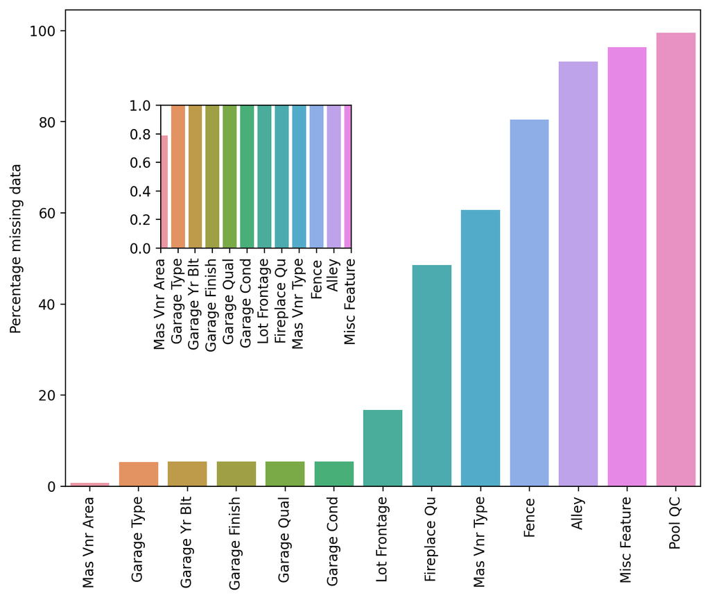

```python
fig = plt.figure(dpi=200)
ax1 = fig.add_axes([0,0,1,1])
ax2 = fig.add_axes([0.15,0.5,0.3,0.3])

sns.barplot(x=percent_nan.index, y=percent_nan, ax=ax1)
ax1.tick_params(axis='x', rotation=90)
ax1.set_ylabel('Percentage missing data')


sns.barplot(x=percent_nan.index, y=percent_nan, ax=ax2)
ax2.set_xlim(0,11)
ax2.set_ylim(0,1)
ax2.tick_params(axis='x', rotation=90)
```

```python
df["Mas Vnr Type"] = df["Mas Vnr Type"].fillna("None")
df["Mas Vnr Area"] = df["Mas Vnr Area"].fillna(0)
```

```python
percent_nan = missing_data(df)
```

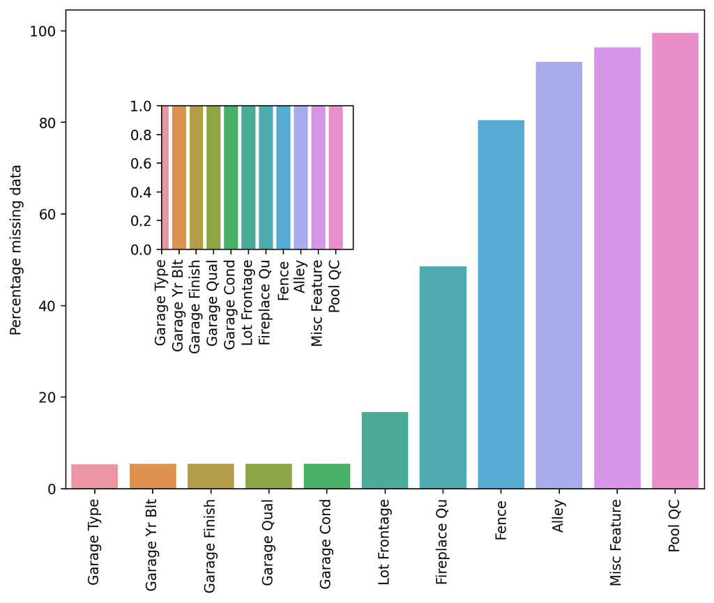

```python
fig = plt.figure(dpi=200)
ax1 = fig.add_axes([0,0,1,1])
ax2 = fig.add_axes([0.15,0.5,0.3,0.3])

sns.barplot(x=percent_nan.index, y=percent_nan, ax=ax1)
ax1.tick_params(axis='x', rotation=90)
ax1.set_ylabel('Percentage missing data')


sns.barplot(x=percent_nan.index, y=percent_nan, ax=ax2)
ax2.set_xlim(0,11)
ax2.set_ylim(0,1)
ax2.tick_params(axis='x', rotation=90)
```

The garage features have the same 'problem' as the bath features. Having no garage is noted as NA. Replacing NA with 'None'

```python
gar_cols = ['Garage Type', 'Garage Finish', 'Garage Qual', 'Garage Cond']

df[gar_cols] = df[gar_cols].fillna('None')
```

```python
percent_nan = missing_data(df)
```

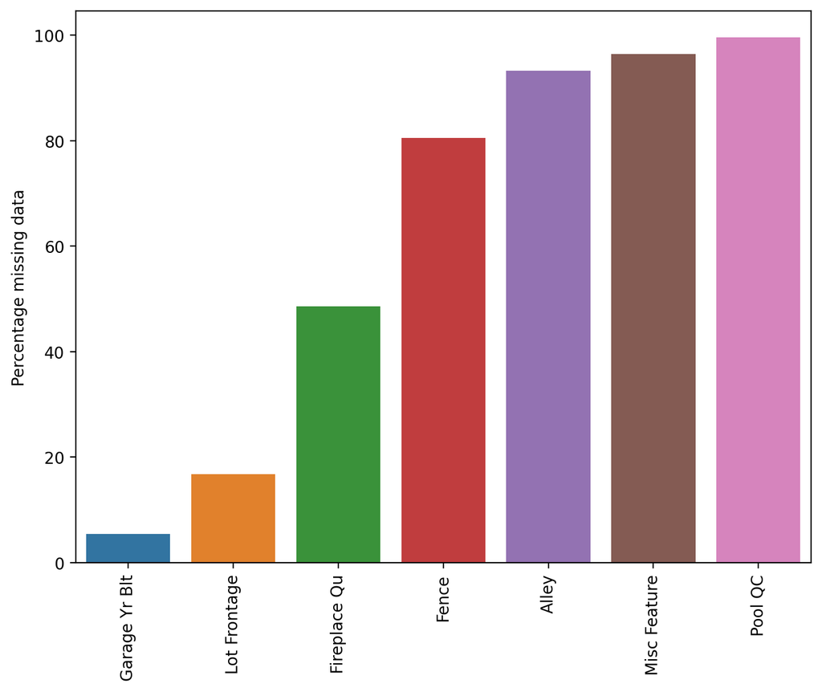

```python
fig = plt.figure(dpi=200)
ax1 = fig.add_axes([0,0,1,1])

sns.barplot(x=percent_nan.index, y=percent_nan, ax=ax1)
ax1.tick_params(axis='x', rotation=90)
ax1.set_ylabel('Percentage missing data')
```

```python
df['Garage Yr Blt'] = df['Garage Yr Blt'].fillna(0)
```

```python
percent_nan = missing_data(df)
```

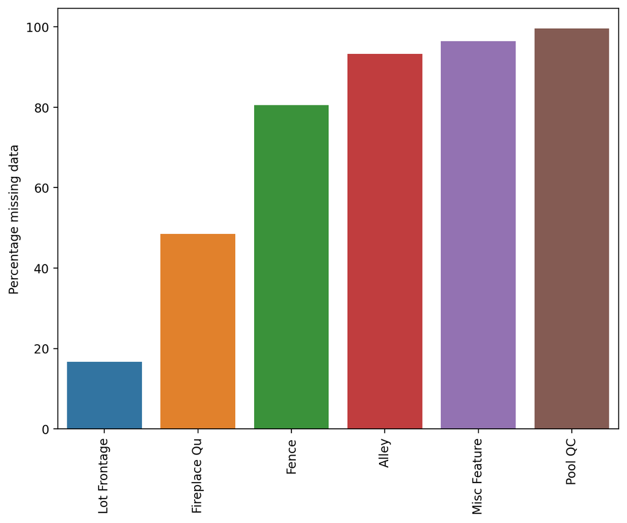

```python
fig = plt.figure(dpi=200)
ax1 = fig.add_axes([0,0,1,1])

sns.barplot(x=percent_nan.index, y=percent_nan, ax=ax1)
ax1.tick_params(axis='x', rotation=90)
ax1.set_ylabel('Percentage missing data')
```

Certain columns have to much missing data, which mean we can drop these.

```python
df = df.drop(['Pool QC', 'Misc Feature', 'Alley', 'Fence'], axis=1)
```

```python
percent_nan = missing_data(df)
```

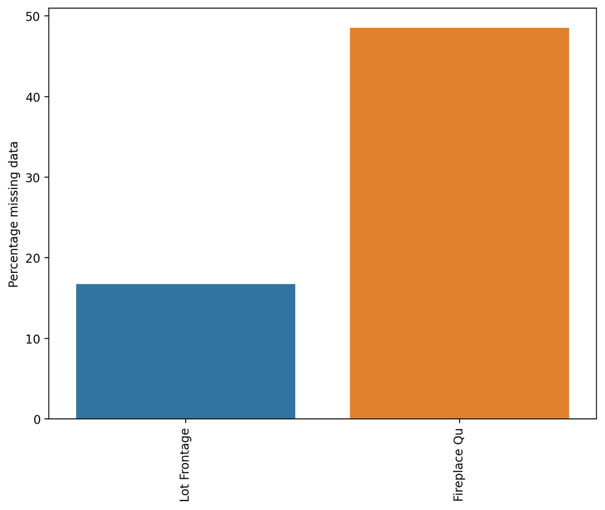

```python
fig = plt.figure(dpi=200)
ax1 = fig.add_axes([0,0,1,1])

sns.barplot(x=percent_nan.index, y=percent_nan, ax=ax1)
ax1.tick_params(axis='x', rotation=90)
ax1.set_ylabel('Percentage missing data')
```

```python
df['Fireplace Qu'].value_counts()
```

```
Fireplace Qu
Gd    741
TA    600
Fa     75
Po     46
Ex     43
Name: count, dtype: int64
```

Fireplace Qu seems to hold strings, NA values again converted to 'None'

```python
df['Fireplace Qu'] = df['Fireplace Qu'].fillna('None')
```

```python
df['Lot Frontage'].value_counts()
```

```
Lot Frontage
60.0     276
80.0     137
70.0     133
50.0     116
75.0     105
        ...
119.0      1
137.0      1
25.0       1
152.0      1
133.0      1
Name: count, Length: 128, dtype: int64
```

Lot frontage is the linear feet of street connected to property. This feature can depend on the neighborhood

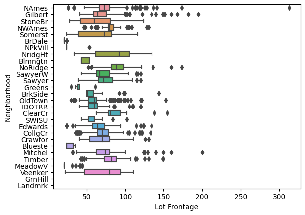

```python
sns.boxplot(data=df, x='Lot Frontage', y='Neighborhood');
```

```python
df.groupby('Neighborhood')['Lot Frontage'].mean()
```

```
Neighborhood
Blmngtn    46.900000
Blueste    27.300000
BrDale     21.500000
BrkSide    55.789474
ClearCr    88.150000
CollgCr    71.336364
Crawfor    69.951807
Edwards    64.794286
Gilbert    74.207207
Greens     41.000000
GrnHill          NaN
IDOTRR     62.383721
Landmrk          NaN
MeadowV    25.606061
Mitchel    75.144444
NAmes      75.210667
NPkVill    28.142857
NWAmes     81.517647
NoRidge    91.629630
NridgHt    84.184049
OldTown    61.777293
SWISU      59.068182
Sawyer     74.551020
SawyerW    70.669811
Somerst    64.549383
StoneBr    62.173913
Timber     81.303571
Veenker    72.000000
Name: Lot Frontage, dtype: float64
```

```python
df['Lot Frontage'] = df.groupby('Neighborhood')['Lot Frontage'].transform(lambda value: value.fillna(value.mean()))
```

```python
df.isnull().sum()
```

```
MS SubClass       0
MS Zoning         0
Lot Frontage      3
Lot Area          0
Street            0
                 ..
Mo Sold           0
Yr Sold           0
Sale Type         0
Sale Condition    0
SalePrice         0
Length: 76, dtype: int64
```

```python
df['Lot Frontage'] = df['Lot Frontage'].fillna(0)
```

```python
percent_nan = missing_data(df)
percent_nan
```

```
Series([], dtype: float64)
```

All missing values have been fixed

Dealing with categorical data

```python
df['MS SubClass'] = df['MS SubClass'].apply(str)
```

```python
df_nums = df.select_dtypes(exclude='object')
df_objs = df.select_dtypes(include='object')
```

```python
df_objs = pd.get_dummies(df_objs,drop_first=True, dtype=int)
```

```python
final_df = pd.concat([df_nums,df_objs],axis=1)
```

### Linear regression model

Separate out the data into X features and y labels and create train-test-split with a future grid search in mind

```python
y = final_df['SalePrice']
X = final_df.drop('SalePrice', axis=1)
```

```python
from sklearn.model_selection import train_test_split
X_train, X_test, y_train, y_test = train_test_split(X,y, test_size=0.1, random_state=101)
```

Scale data for regression

```python
from sklearn.preprocessing import StandardScaler
scaler = StandardScaler()
```

```python
scaler.fit(X_train);
```

```python
scaled_X_train = scaler.transform(X_train)
scaled_X_test = scaler.transform(X_test)
```

ElasticNet regression - Grid search

```python
from sklearn.linear_model import ElasticNet
base_elastic_model = ElasticNet(max_iter=1000000)
```

```python
param_grid = {'alpha':[0.1,1,5,10,50,100], 'l1_ratio':[.1, .5, .7, .9, .95, .99, 1]}
```

```python
from sklearn.model_selection import GridSearchCV
grid_search = GridSearchCV(estimator=base_elastic_model, param_grid=param_grid, scoring='neg_mean_squared_error', cv = 5, verbose=2)
```

```python
grid_search.fit(scaled_X_train,y_train);
```

[output not shown]

[output cut: 156 more lines]

```
[CV] END ...........................alpha=100, l1_ratio=0.95; total time=   0.0s
[CV] END ...........................alpha=100, l1_ratio=0.95; total time=   0.0s
[CV] END ...........................alpha=100, l1_ratio=0.95; total time=   0.0s
[CV] END ...........................alpha=100, l1_ratio=0.95; total time=   0.0s
[CV] END ...........................alpha=100, l1_ratio=0.95; total time=   0.0s
[CV] END ...........................alpha=100, l1_ratio=0.99; total time=   0.0s
[CV] END ...........................alpha=100, l1_ratio=0.99; total time=   0.0s
[CV] END ...........................alpha=100, l1_ratio=0.99; total time=   0.0s
[CV] END ...........................alpha=100, l1_ratio=0.99; total time=   0.0s
[CV] END ...........................alpha=100, l1_ratio=0.99; total time=   0.0s
[CV] END ..............................alpha=100, l1_ratio=1; total time=   0.0s
[CV] END ..............................alpha=100, l1_ratio=1; total time=   0.0s
[CV] END ..............................alpha=100, l1_ratio=1; total time=   0.0s
[CV] END ..............................alpha=100, l1_ratio=1; total time=   0.0s
[CV] END ..............................alpha=100, l1_ratio=1; total time=   0.0s
```

```python
grid_search.best_params_
```

```
{'alpha': 100, 'l1_ratio': 1}
```

```python
y_pred = grid_search.predict(scaled_X_test);
```

Evaluating the model

```python
from sklearn.metrics import mean_absolute_error,mean_squared_error
MAE = mean_absolute_error(y_test, y_pred)
RMSE = np.sqrt(mean_squared_error(y_test, y_pred))

print(MAE)
print(RMSE)
```

```
14195.35490056217
20558.508566893164
```

```python
np.mean(df['SalePrice'])
```

```
180815.53743589742
```

### Saving the model

```python
from joblib import dump

dump(grid_search, 'Elast_Net_Model_Price_Prediction.joblib')
```

```
['Elast_Net_Model_Price_Prediction.joblib']
```